# Análisis de Consumo de Café en UTEC

Estadística y Probabilidades I · Ciclo 2026-0

Autores/as

Silvera Pastor, Jose Maria

Oliden Serrato, Ronald Amir

Alvarez Lovera, Sandra Sofia

Baquerizo Rojas, Valeria Marisol

Cose Rojas, Joseph Anderson

Fecha de publicación

22 de febrero de 2026

# **Hábitos de consumo de café de los estudiantes de UTEC y su relación con la vida académica durante el periodo 2024-2**

# I. Introducción

## I.1 Relevancia

El café es una parte importante de la rutina diaria de muchos estudiantes de UTEC, ayudándoles a mantenerse despiertos y concentrados durante sus actividades académicas. Aunque su consumo puede traer beneficios, el exceso puede resultar perjudicial. La Organización Mundial de la Salud (OMS) recomienda no consumir más de cuatro tazas diarias (~400 mg de cafeína); superarlo puede alterar el sueño, incrementar el estrés y reducir el bienestar general. Conocer los hábitos de consumo de los estudiantes es fundamental para comprender su impacto en la experiencia universitaria.

## I.2 Planificación

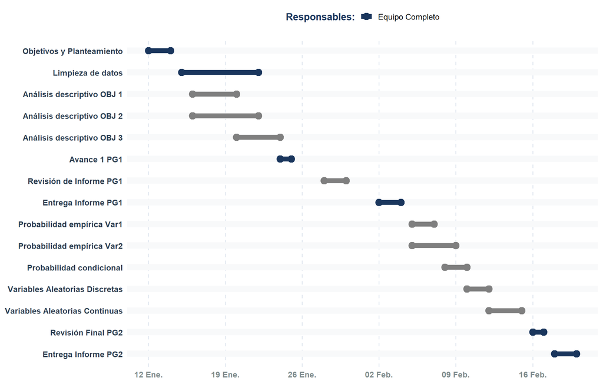

Figura 1: Cronograma de Actividades del Proyecto

```r
library(ggplot2)

datos_gantt <- data.frame(
  Tarea = c(
    "Objetivos y Planteamiento", "Limpieza de datos", "Avance 1 PG1",
    "Análisis descriptivo OBJ 1", "Análisis descriptivo OBJ 2", "Análisis descriptivo OBJ 3",
    "Revisión de Informe PG1", "Entrega Informe PG1",
    "Probabilidad empírica Var1", "Probabilidad empírica Var2",
    "Probabilidad condicional", "Variables Aleatorias Discretas",
    "Variables Aleatorias Continuas", "Revisión Final PG2", "Entrega Informe PG2"
  ),
  Responsable = c(
    "Equipo Completo", "Equipo Completo", "Equipo Completo",
    "José", "Joseph", "Ronald",
    "Valeria", "Equipo Completo",
    "José", "Sandra",
    "Sandra", "Ronald",
    "José", "Equipo Completo", "Equipo Completo"
  ),
  Inicio = as.Date(c(
    "2026-01-12", "2026-01-15", "2026-01-24",
    "2026-01-16", "2026-01-16", "2026-01-20",
    "2026-01-28", "2026-02-02",
    "2026-02-05", "2026-02-05",
    "2026-02-08", "2026-02-10",
    "2026-02-12", "2026-02-16", "2026-02-18"
  )),
  Fin = as.Date(c(
    "2026-01-14", "2026-01-22", "2026-01-25",
    "2026-01-20", "2026-01-22", "2026-01-24",
    "2026-01-30", "2026-02-04",
    "2026-02-07", "2026-02-09",
    "2026-02-10", "2026-02-12",
    "2026-02-15", "2026-02-17", "2026-02-20"
  ))
)

datos_gantt <- datos_gantt[order(datos_gantt$Inicio, datos_gantt$Fin, decreasing = TRUE), ]
datos_gantt$Tarea <- factor(datos_gantt$Tarea, levels = unique(datos_gantt$Tarea))

ggplot(datos_gantt, aes(x = Inicio, xend = Fin, y = Tarea, yend = Tarea, color = Responsable)) +
  geom_hline(yintercept = seq_along(datos_gantt$Tarea), color = "#F8F9FA", linewidth = 4) +
  geom_segment(linewidth = 3) +
  geom_point(aes(x = Inicio), size = 4) +
  geom_point(aes(x = Fin), size = 4) +
  scale_color_manual(values = c(
    "Equipo Completo" = "#1A365D",
    "Estudiante 1" = "#3B82F6",
    "Estudiante 2" = "#10B981",
    "Estudiante 3" = "#F59E0B",
    "Estudiante 4" = "#8B5CF6"
  )) +
  scale_x_date(date_breaks = "1 week", date_labels = "%d %b") +
  labs(x = NULL, y = NULL, color = "Responsables:") +
  theme_minimal(base_size = 13) +
  theme(
    legend.position = "top",
    legend.title = element_text(face = "bold", color = "#1A365D"),
    panel.grid.major.y = element_blank(),
    panel.grid.minor = element_blank(),
    panel.grid.major.x = element_line(color = "#E2E8F0", linetype = "dashed"),
    axis.text.y = element_text(face = "bold", color = "#2C3E50", margin = margin(r = 10)),
    axis.text.x = element_text(face = "bold", color = "#7F8C8D")
  )
```

## I.3 Objetivos

### I.3.1 Objetivo general

Analizar los hábitos de consumo de café de los estudiantes de UTEC durante el periodo académico 2024-2 y su relación con indicadores académicos y de bienestar.

### I.3.2 Objetivos específicos

- **OE1:** Analizar la relación entre la frecuencia de consumo de café y los niveles de estrés percibidos, diferenciando por sexo.
- **OE2:** Analizar la relación entre los patrones de sueño y el rendimiento académico.
- **OE3:** Determinar si el ingreso a la universidad influyó en los hábitos de consumo de café.

# II. Datos

## II.1 Población objetivo

Todos los estudiantes matriculados en la UTEC durante el periodo académico 2024-2.

## II.2 Unidad muestral

Cada estudiante de UTEC en el periodo 2024-2 que consume café.

## II.3 Tipo de muestreo

Muestreo no probabilístico por conveniencia mediante encuesta estructurada.

## II.4 Tratamiento de datos

Los datos provienen de una encuesta aplicada a estudiantes de UTEC durante 2024-2, exportada a CSV para análisis en RStudio.

```r
if (!require(readr))     install.packages("readr")
if (!require(dplyr))     install.packages("dplyr")
if (!require(tidyr))     install.packages("tidyr")
if (!require(ggplot2))   install.packages("ggplot2")
if (!require(knitr))     install.packages("knitr")
if (!require(kableExtra))install.packages("kableExtra")
if (!require(e1071))     install.packages("e1071")

library(readr)
library(dplyr)
library(tidyr)
library(ggplot2)
library(knitr)
library(kableExtra)
library(e1071)
```

```r
CAFE <- read_csv("DATACAFE.csv")

# Filtrar consumidores de café
SI_CAFE <- filter(CAFE, `¿Consume café?` == "Sí" | `¿Consume café?` == "si")

# Renombrar variables
SI_CAFE <- rename(SI_CAFE,
  sexo = "Sexo", consume_cafe = "¿Consume café?",
  tazas_dia = "En promedio ¿Cuántas tazas de café consumes en un día?",
  tazas_antes = "Antes de ser alumno de UTEC, ¿cuántas tazas de café consumías al día aproximadamente?",
  tazas_examen = "Durante un día de exámenes, ¿Cuántas tazas de café consumes?",
  frec_diaria = "¿Con qué frecuencia tomas café diariamente?",
  pp_2024_1 = "¿Cuál fue tu promedio ponderado en el ciclo 2024-1? (Tal cual aparece en tu intranet de estudiante).",
  limite_dormir = "¿Cuál es la cantidad máxima de horas antes de dormir en la que consumirías café?",
  efecto = "¿Cómo crees que te afecta el consumo de café?",
  cafe_noche = "¿Con qué frecuencia consumes café por la noche?",
  sueno_noche = "¿Cuántas horas duermes por la noche en promedio cuando consumes café?",
  estres = "¿Tu nivel de estrés cambia cuándo consumes café?",
  estres_cambio = "Si la respuesta anterior fue sí. ¿Cómo ha cambiado tu nivel de estrés después de consumir café?",
  energia_1_a_5 = "En una escala del 1 al 5, ¿Cómo calificarías el nivel de energía que sientes después de consumir café?\n1: No me brinda nada de energía\n3: Neutral\n5: Me brinda mucha energía",
  bienestar = "¿Consideras que el consumo de café tiene algún efecto en tu bienestar físico o mental?",
  cambio_utec = "¿Tu consumo de café cambió al ingresar a la universidad?"
)

# Tipificar variables
SI_CAFE$sexo         <- factor(tolower(trimws(SI_CAFE$sexo)))
SI_CAFE$estres       <- factor(SI_CAFE$estres)
SI_CAFE$bienestar    <- factor(SI_CAFE$bienestar)
SI_CAFE$efecto       <- factor(SI_CAFE$efecto)
SI_CAFE$frec_diaria  <- factor(SI_CAFE$frec_diaria,
  levels = c("Nunca","Rara vez","A veces","Frecuentemente","Siempre"))
SI_CAFE$cafe_noche   <- factor(SI_CAFE$cafe_noche,
  levels = c("Nunca","Rara vez","A veces","Frecuentemente","Siempre"))
SI_CAFE$estres_cambio <- factor(SI_CAFE$estres_cambio,
  levels = c("Disminuye","Neutro","Aumenta"))
SI_CAFE$cambio_utec  <- factor(SI_CAFE$cambio_utec,
  levels = c("Disminuyó mucho","Disminuyó","No cambio","Aumentó","Aumentó mucho"))
SI_CAFE$energia_1_a_5 <- factor(SI_CAFE$energia_1_a_5, ordered = TRUE,
  levels = c("1","2","3","4","5"))
SI_CAFE$tazas_dia    <- as.integer(SI_CAFE$tazas_dia)
SI_CAFE$tazas_antes  <- as.integer(SI_CAFE$tazas_antes)
SI_CAFE$tazas_examen <- as.integer(SI_CAFE$tazas_examen)
SI_CAFE$sueno_noche  <- as.integer(SI_CAFE$sueno_noche)
SI_CAFE$limite_dormir <- as.integer(SI_CAFE$limite_dormir)
SI_CAFE$pp_2024_1    <- as.double(SI_CAFE$pp_2024_1)
```

## II.5 Limpieza

Se aplicaron filtros por rangos fisiológicamente válidos: tazas/día 0–15, horas de sueño 1–12, pp 0–20, energía 1–5.

```r
n_pre <- nrow(SI_CAFE)

CAFE_OFICIAL <- SI_CAFE %>%
  select(sexo, tazas_dia, frec_diaria, cafe_noche, tazas_antes, tazas_examen,
         sueno_noche, limite_dormir, estres, estres_cambio,
         pp_2024_1, energia_1_a_5, bienestar, efecto, cambio_utec) %>%
  filter(
    tazas_dia     >= 0 & tazas_dia     <= 15,
    tazas_antes   >= 0 & tazas_antes   <= 20,
    tazas_examen  >= 0 & tazas_examen  <= 20,
    sueno_noche   >= 1 & sueno_noche   <= 12,
    limite_dormir >= 0 & limite_dormir <= 24,
    pp_2024_1     >= 0 & pp_2024_1     <= 20,
    energia_1_a_5 %in% c("1","2","3","4","5")
  )

n_post <- nrow(CAFE_OFICIAL)
cat("Obs. antes de limpieza:", n_pre, "| Después:", n_post,
    "| Pérdida:", round((n_pre - n_post)/n_pre*100, 1), "%\n")
```

```
Obs. antes de limpieza: 1390 | Después: 1248 | Pérdida: 10.2 %
```

```r
cat("Filas completas (sin NA en ninguna variable):", sum(complete.cases(CAFE_OFICIAL)), "\n")
```

```
Filas completas (sin NA en ninguna variable): 935
```

## II.4 Variables

| Variable | Tipo | Restricción |
| --- | --- | --- |
| sexo | Cualit. nominal | femenino/masculino |
| tazas_dia | Cuant. discreta | 0–15 |
| pp_2024_1 | Cuant. continua | 0–20 |
| sueno_noche | Cuant. discreta | 1–12 |
| limite_dormir | Cuant. discreta | 0–24 |
| frec_diaria | Cualit. ordinal | Nunca < … < Siempre |
| cafe_noche | Cualit. ordinal | Nunca < … < Siempre |
| estres_cambio | Cualit. ordinal | Disminuye/Neutro/Aumenta |
| energia_1_a_5 | Cualit. ordinal | 1–5 (Likert, no se promedia) |
| cambio_utec | Cualit. ordinal | Disminuyó mucho < … < Aumentó mucho |

# III. Análisis Descriptivo

## III.1 Organización de datos - Análisis univariado

```r
vars_num <- CAFE_OFICIAL %>%
  select(tazas_dia, pp_2024_1, sueno_noche)

est <- data.frame(
  Variable = names(vars_num),
  Media    = sapply(vars_num, mean, na.rm=TRUE),
  Mediana  = sapply(vars_num, median, na.rm=TRUE),
  DE       = sapply(vars_num, sd, na.rm=TRUE)
) %>% mutate(across(where(is.numeric), ~round(., 2)))

kable(est, caption = "Tabla 1. Estadísticos descriptivos", align = c("l", rep("r",3))) %>%
  kable_styling(bootstrap_options = c("striped","hover"), full_width = FALSE)
```

Tabla 1. Estadísticos descriptivos

|  | Variable | Media | Mediana | DE |
| --- | --- | --- | --- | --- |
| tazas_dia | tazas_dia | 2.20 | 2 | 1.60 |
| pp_2024_1 | pp_2024_1 | 14.69 | 15 | 2.17 |
| sueno_noche | sueno_noche | 5.68 | 6 | 1.56 |

**Interpretación:** El consumo típico es de 2.20 tazas/día (mediana 2), el rendimiento académico promedio es 14.69/20, y las horas de sueño promedian 5.68 h (por debajo de las 7–8 recomendadas).

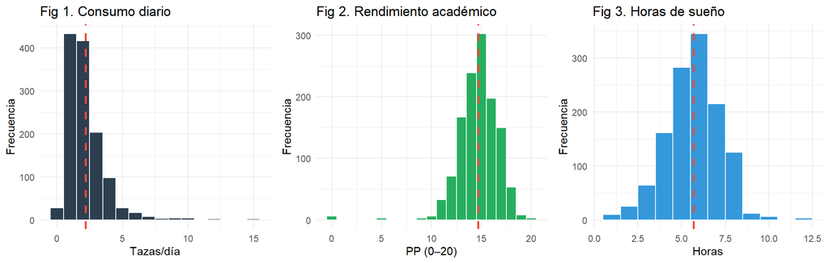

```r
library(gridExtra)

p1 <- ggplot(CAFE_OFICIAL, aes(x=tazas_dia)) +
  geom_histogram(binwidth=1, fill="#2C3E50", color="white") +
  geom_vline(aes(xintercept=mean(tazas_dia, na.rm=TRUE)), color="#E74C3C", linetype="dashed", linewidth=1) +
  labs(title="Fig 1. Consumo diario", x="Tazas/día", y="Frecuencia") + theme_minimal()

p2 <- ggplot(CAFE_OFICIAL, aes(x=pp_2024_1)) +
  geom_histogram(binwidth=1, fill="#27AE60", color="white") +
  geom_vline(aes(xintercept=mean(pp_2024_1, na.rm=TRUE)), color="#E74C3C", linetype="dashed", linewidth=1) +
  labs(title="Fig 2. Rendimiento académico", x="PP (0–20)", y="Frecuencia") + theme_minimal()

p3 <- ggplot(CAFE_OFICIAL, aes(x=sueno_noche)) +
  geom_histogram(binwidth=1, fill="#3498DB", color="white") +
  geom_vline(aes(xintercept=mean(sueno_noche, na.rm=TRUE)), color="#E74C3C", linetype="dashed", linewidth=1) +
  labs(title="Fig 3. Horas de sueño", x="Horas", y="Frecuencia") + theme_minimal()

grid.arrange(p1, p2, p3, ncol=3)
```

## III.2 Medidas de resumen - Análisis bivariado

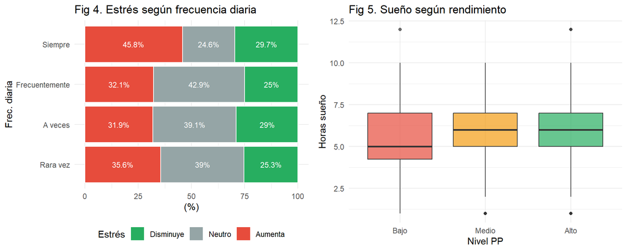

```r
OBJ1 <- CAFE_OFICIAL %>%
  select(sexo, cafe_noche, estres_cambio, frec_diaria) %>%
  filter(complete.cases(.))

p4 <- OBJ1 %>%
  count(frec_diaria, estres_cambio) %>% group_by(frec_diaria) %>%
  mutate(porc = n/sum(n)*100) %>%
  ggplot(aes(x=frec_diaria, y=porc, fill=estres_cambio)) +
  geom_col(color="white") +
  geom_text(aes(label=paste0(round(porc,1),"%")), position=position_stack(vjust=0.5), color="white", size=3) +
  coord_flip() +
  scale_fill_manual(values=c("Disminuye"="#27AE60","Neutro"="#95A5A6","Aumenta"="#E74C3C")) +
  labs(title="Fig 4. Estrés según frecuencia diaria", x="Frec. diaria", y="(%)", fill="Estrés") +
  theme_minimal() + theme(legend.position="bottom")

OBJ2 <- CAFE_OFICIAL %>%
  select(sueno_noche, pp_2024_1) %>%
  filter(complete.cases(.)) %>%
  mutate(grupo_pp = case_when(pp_2024_1 <= 12 ~ "Bajo", pp_2024_1 < 15 ~ "Medio", TRUE ~ "Alto"),
         grupo_pp = factor(grupo_pp, levels=c("Bajo","Medio","Alto")))

p5 <- ggplot(OBJ2, aes(x=grupo_pp, y=sueno_noche, fill=grupo_pp)) +
  geom_boxplot(alpha=0.7) +
  scale_fill_manual(values=c("#E74C3C","#F39C12","#27AE60")) +
  labs(title="Fig 5. Sueño según rendimiento", x="Nivel PP", y="Horas sueño") +
  theme_minimal() + theme(legend.position="none")

grid.arrange(p4, p5, ncol=2)
```

# IV. Análisis Probabilístico

## IV.1 Probabilidad empírica

### IV.1.1 Variable: Frecuencia diaria de consumo (`frec_diaria`)

**Definición de rangos/categorías:**

Para analizar la frecuencia de consumo, se emplean las categorías ordinales originales de la encuesta: Nunca, Rara vez, A veces, Frecuentemente, Siempre.

**Experimento aleatorio:**

$E:$ Seleccionar al azar a un estudiante de la muestra limpia y registrar su frecuencia diaria de consumo de café.

**Espacio muestral:**

$$\Omega = \{\text{Nunca, Rara vez, A veces, Frecuentemente, Siempre}\}$$

**Eventos atómicos:**

- $E_1:$ Seleccionar un estudiante cuya frecuencia sea “Nunca”
- $E_2:$ Seleccionar un estudiante cuya frecuencia sea “Rara vez”
- $E_3:$ Seleccionar un estudiante cuya frecuencia sea “A veces”
- $E_4:$ Seleccionar un estudiante cuya frecuencia sea “Frecuentemente”
- $E_5:$ Seleccionar un estudiante cuya frecuencia sea “Siempre”

**Cálculo de probabilidades empíricas:**

Fórmula: $P(\omega_i) = \frac{\text{casos favorables}}{\text{casos totales}}$

```r
espacio_muestral <- nrow(CAFE_OFICIAL %>% filter(!is.na(frec_diaria)))

frec_tabla <- CAFE_OFICIAL %>%
  filter(!is.na(frec_diaria)) %>%
  count(frec_diaria) %>%
  mutate(Probabilidad = round(n / espacio_muestral, 4))

kable(frec_tabla, caption = "Tabla 2. Probabilidades empíricas - Frecuencia diaria",
      col.names = c("Categoría (ω)", "Frecuencia", "P(ω)"), align = c("l","r","r")) %>%
  kable_styling(bootstrap_options = c("striped","hover"), full_width = FALSE)
```

Tabla 2. Probabilidades empíricas - Frecuencia diaria

| Categoría (ω) | Frecuencia | P(ω) |
| --- | --- | --- |
| Rara vez | 187 | 0.1498 |
| A veces | 450 | 0.3606 |
| Frecuentemente | 449 | 0.3598 |
| Siempre | 162 | 0.1298 |

**Validación de suma de probabilidades:**

```r
suma_prob <- sum(frec_tabla$Probabilidad)
cat("Suma de probabilidades:", round(suma_prob, 4), "\n")
```

```
Suma de probabilidades: 1
```

```r
if (round(suma_prob, 2) == 1.00) {
  cat("✓ Verificación correcta: Σ P(ωi) = 1\n")
} else {
  cat("✗ ERROR: La suma no es igual a 1\n")
}
```

```
✓ Verificación correcta: Σ P(ωi) = 1
```

**Visualización:**

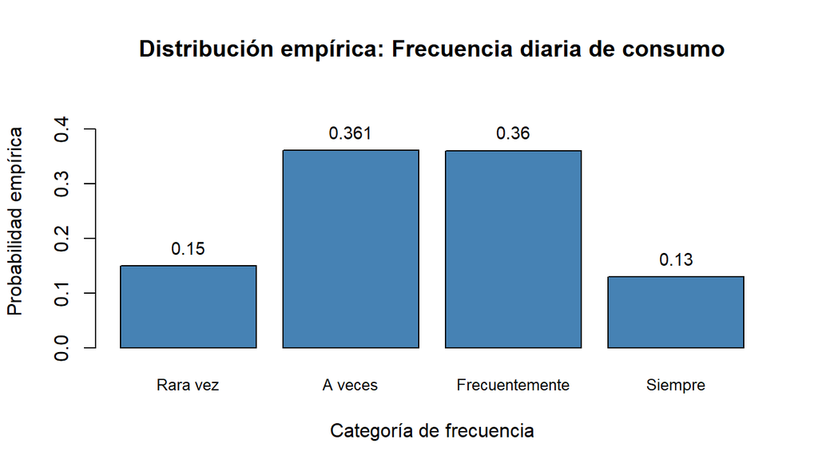

```r
bp1 <- barplot(
  frec_tabla$Probabilidad,
  names.arg = frec_tabla$frec_diaria,
  col = "steelblue",
  xlab = "Categoría de frecuencia",
  ylab = "Probabilidad empírica",
  ylim = c(0, max(frec_tabla$Probabilidad) + 0.1),
  main = "Distribución empírica: Frecuencia diaria de consumo",
  cex.names = 0.8
)
text(x = bp1, y = frec_tabla$Probabilidad, labels = round(frec_tabla$Probabilidad, 3),
     pos = 3, cex = 0.9)
```

**Interpretación:**

### IV.1.2 Variable: Tazas de café por día (`tazas_dia`)

**Definición de rangos/categorías:**

Se agrupan las tazas consumidas en tres niveles de consumo basados en recomendaciones de salud:

- **Consumo bajo:** 0–2 tazas (dentro del rango saludable)
- **Consumo moderado:** 3–4 tazas (límite recomendado por OMS)
- **Consumo alto:** 5 o más tazas (por encima del límite saludable)

```r
CAFE_PROB <- CAFE_OFICIAL %>%
  filter(!is.na(tazas_dia)) %>%
  mutate(
    categoria_consumo = case_when(
      tazas_dia <= 2 ~ "Consumo bajo",
      tazas_dia <= 4 ~ "Consumo moderado",
      TRUE           ~ "Consumo alto"
    ) %>% factor(levels = c("Consumo bajo", "Consumo moderado", "Consumo alto"))
  )
```

**Experimento aleatorio:**

$E:$ Seleccionar al azar a un estudiante de la muestra limpia y registrar su nivel de consumo diario de café.

**Espacio muestral:**

$$\Omega = \{\text{Consumo bajo, Consumo moderado, Consumo alto}\}$$

**Eventos atómicos:**

- $E_1:$ Seleccionar un estudiante cuyo consumo sea bajo (0–2 tazas)
- $E_2:$ Seleccionar un estudiante cuyo consumo sea moderado (3–4 tazas)
- $E_3:$ Seleccionar un estudiante cuyo consumo sea alto (≥5 tazas)

**Cálculo de probabilidades empíricas:**

```r
espacio_muestral2 <- nrow(CAFE_PROB)

consumo_tabla <- CAFE_PROB %>%
  count(categoria_consumo) %>%
  mutate(Probabilidad = round(n / espacio_muestral2, 4))

kable(consumo_tabla, caption = "Tabla 3. Probabilidades empíricas - Nivel de consumo",
      col.names = c("Nivel de consumo (ω)", "Frecuencia", "P(ω)"), align = c("l","r","r")) %>%
  kable_styling(bootstrap_options = c("striped","hover"), full_width = FALSE)
```

Tabla 3. Probabilidades empíricas - Nivel de consumo

| Nivel de consumo (ω) | Frecuencia | P(ω) |
| --- | --- | --- |
| Consumo bajo | 877 | 0.7027 |
| Consumo moderado | 301 | 0.2412 |
| Consumo alto | 70 | 0.0561 |

**Validación de suma de probabilidades:**

```r
suma_prob2 <- sum(consumo_tabla$Probabilidad)
cat("Suma de probabilidades:", round(suma_prob2, 4), "\n")
```

```
Suma de probabilidades: 1
```

```r
if (round(suma_prob2, 2) == 1.00) {
  cat("✓ Verificación correcta: Σ P(ωi) = 1\n")
} else {
  cat("✗ ERROR: La suma no es igual a 1\n")
}
```

```
✓ Verificación correcta: Σ P(ωi) = 1
```

**Visualización:**

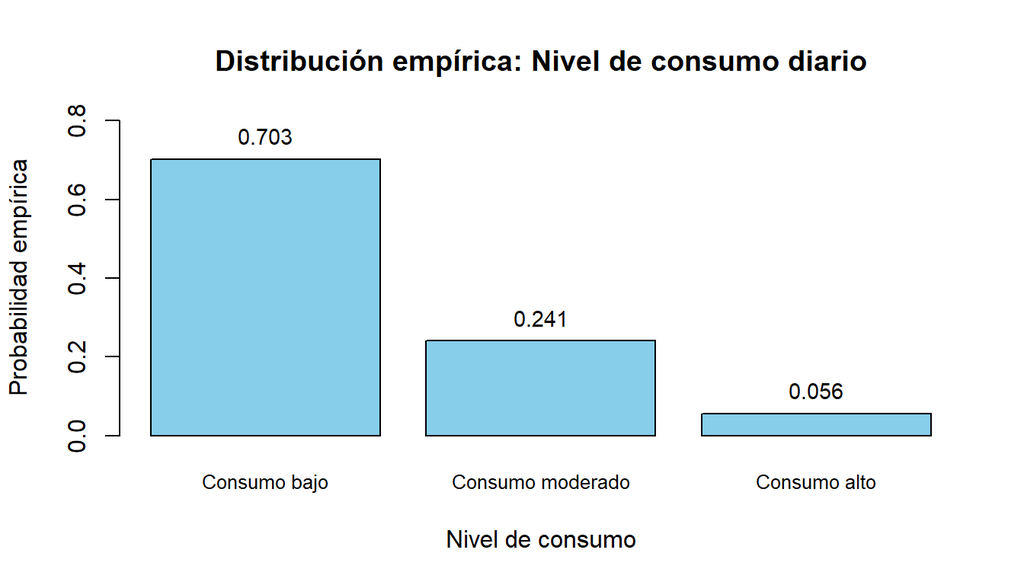

```r
bp2 <- barplot(
  consumo_tabla$Probabilidad,
  names.arg = consumo_tabla$categoria_consumo,
  col = "skyblue",
  xlab = "Nivel de consumo",
  ylab = "Probabilidad empírica",
  ylim = c(0, max(consumo_tabla$Probabilidad) + 0.1),
  main = "Distribución empírica: Nivel de consumo diario",
  cex.names = 0.8
)
text(x = bp2, y = consumo_tabla$Probabilidad, labels = round(consumo_tabla$Probabilidad, 3),
     pos = 3, cex = 0.9)
```

**Interpretación:**

## IV.2 Probabilidad condicional

**Contexto:**

Se desea analizar la relación entre el aumento del consumo de café al ingresar a UTEC y la percepción de alta energía. Esto permitirá determinar si ambos eventos están asociados.

**Definición de eventos:**

**Evento A:** “El consumo de café del estudiante aumentó al ingresar a UTEC”

- Se considera que A ocurre si `cambio_utec` es “Aumentó” o “Aumentó mucho”

**Evento B:** “El estudiante percibe alta energía después de consumir café”

- Se considera que B ocurre si `energia_1_a_5` es “4” o “5”

```r
df_cond <- CAFE_OFICIAL %>%
  filter(!is.na(cambio_utec), !is.na(energia_1_a_5)) %>%
  mutate(
    A = cambio_utec %in% c("Aumentó", "Aumentó mucho"),
    B = energia_1_a_5 %in% c("4", "5")
  )
```

**Cálculo de probabilidades:**

```r
# Probabilidades individuales
PA   <- mean(df_cond$A)
PB   <- mean(df_cond$B)

# Intersección
PAB  <- mean(df_cond$A & df_cond$B)

# Unión (aplicando fórmula)
PAuB <- PA + PB - PAB

# Complemento de A
PAc  <- 1 - PA

# Intersección con complemento
PBinterAc <- mean(df_cond$B & !df_cond$A)

# Condicionales
PBdA  <- PAB / PA           # P(B|A)
PBdAc <- PBinterAc / PAc    # P(B|Aᶜ)

# Teorema de Bayes con probabilidad total
PAdB_Bayes <- (PBdA * PA) / ((PBdA * PA) + (PBdAc * PAc))

resultados <- data.frame(
  Cantidad = c("P(A) – Consumo aumentó",
               "P(B) – Energía alta",
               "P(A ∩ B)",
               "P(A ∪ B)",
               "P(A)·P(B) – Si fueran independientes",
               "P(Aᶜ)",
               "P(B ∩ Aᶜ)",
               "P(B|A)",
               "P(B|Aᶜ)",
               "P(A|B) – por Teorema de Bayes"),
  Valor = round(c(PA, PB, PAB, PAuB, PA*PB, PAc, PBinterAc, PBdA, PBdAc, PAdB_Bayes), 4)
)

kable(resultados, caption = "Tabla 4. Cálculos de probabilidades",
      col.names = c("Cantidad", "Valor"), align = c("l","r")) %>%
  kable_styling(bootstrap_options = c("striped","hover"), full_width = FALSE)
```

Tabla 4. Cálculos de probabilidades

| Cantidad | Valor |
| --- | --- |
| P(A) – Consumo aumentó | 0.6474 |
| P(B) – Energía alta | 0.5393 |
| P(A ∩ B) | 0.4127 |
| P(A ∪ B) | 0.7740 |
| P(A)·P(B) – Si fueran independientes | 0.3491 |
| P(Aᶜ) | 0.3526 |
| P(B ∩ Aᶜ) | 0.1266 |
| P(B&#124;A) | 0.6374 |
| P(B&#124;Aᶜ) | 0.3591 |
| P(A&#124;B) – por Teorema de Bayes | 0.7652 |

**Prueba de independencia:**

```r
cat("P(A ∩ B) =", round(PAB, 4), "\n")
```

```
P(A ∩ B) = 0.4127
```

```r
cat("P(A)·P(B) =", round(PA * PB, 4), "\n")
```

```
P(A)·P(B) = 0.3491
```

```r
cat("\n")
```

```r
if (abs(PAB - (PA * PB)) < 0.001) {
  cat("Los eventos A y B son INDEPENDIENTES\n")
} else {
  cat("Los eventos A y B son DEPENDIENTES\n")
  cat("Diferencia:", round(abs(PAB - (PA * PB)), 4), "\n")
}
```

```
Los eventos A y B son DEPENDIENTES
Diferencia: 0.0635
```

**Análisis de probabilidad condicional:**

```r
cat("P(B|A) =", round(PBdA, 4), "→", round(PBdA * 100, 2), "%\n")
```

```
P(B|A) = 0.6374 → 63.74 %
```

```r
cat("P(B)   =", round(PB, 4), "  →", round(PB * 100, 2), "%\n")
```

```
P(B)   = 0.5393   → 53.93 %
```

```r
cat("\n")
```

```r
factor_cambio <- PBdA / PB
cat("Factor de cambio: P(B|A) / P(B) =", round(factor_cambio, 3), "\n")
```

```
Factor de cambio: P(B|A) / P(B) = 1.182
```

```r
if (factor_cambio > 1) {
  cat("Interpretación: Dado que el consumo aumentó, la probabilidad de\n")
  cat("percibir alta energía AUMENTA en", round((factor_cambio - 1) * 100, 1), "%\n")
} else {
  cat("Interpretación: Dado que el consumo aumentó, la probabilidad de\n")
  cat("percibir alta energía DISMINUYE en", round((1 - factor_cambio) * 100, 1), "%\n")
}
```

```
Interpretación: Dado que el consumo aumentó, la probabilidad de
percibir alta energía AUMENTA en 18.2 %
```

**Teorema de Bayes - Análisis inverso:**

```r
cat("P(A|B) por Bayes =", round(PAdB_Bayes, 4), "→", round(PAdB_Bayes * 100, 2), "%\n")
```

```
P(A|B) por Bayes = 0.7652 → 76.52 %
```

```r
cat("P(A)             =", round(PA, 4), "  →", round(PA * 100, 2), "%\n")
```

```
P(A)             = 0.6474   → 64.74 %
```

```r
cat("\n")
```

```r
factor_cambio2 <- PAdB_Bayes / PA
cat("Factor de cambio: P(A|B) / P(A) =", round(factor_cambio2, 3), "\n")
```

```
Factor de cambio: P(A|B) / P(A) = 1.182
```

```r
cat("\nInterpretación: Entre quienes perciben alta energía, la probabilidad\n")
```

```
Interpretación: Entre quienes perciben alta energía, la probabilidad
```

```r
cat("de que su consumo haya aumentado al entrar a UTEC es del", round(PAdB_Bayes * 100, 1), "%\n")
```

```
de que su consumo haya aumentado al entrar a UTEC es del 76.5 %
```

**Visualización:**

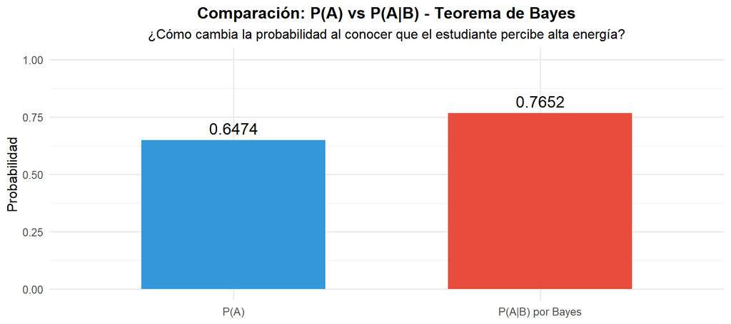

```r
datos_comp <- data.frame(
  Evento = c("P(A)", "P(A|B) por Bayes"),
  Probabilidad = c(PA, PAdB_Bayes)
)

ggplot(datos_comp, aes(x = Evento, y = Probabilidad, fill = Evento)) +
  geom_bar(stat = "identity", width = 0.6) +
  geom_text(aes(label = round(Probabilidad, 4)), vjust = -0.5, size = 5) +
  ylim(0, 1) +
  scale_fill_manual(values = c("P(A)" = "#3498DB", "P(A|B) por Bayes" = "#E74C3C")) +
  labs(title = "Comparación: P(A) vs P(A|B) - Teorema de Bayes",
       subtitle = "¿Cómo cambia la probabilidad al conocer que el estudiante percibe alta energía?",
       y = "Probabilidad", x = NULL) +
  theme_minimal(base_size = 12) +
  theme(legend.position = "none",
        plot.title = element_text(face = "bold", hjust = 0.5),
        plot.subtitle = element_text(hjust = 0.5))
```

**Conclusión:**

# V. Variables Aleatorias

## V.1 Variables discretas

### V.1.1 Tazas por día (`tazas_dia`)

**Caso práctico:**

Un investigador de la oficina de Bienestar Estudiantil de UTEC desea estimar la probabilidad de que un estudiante seleccionado al azar consuma exactamente 3 tazas de café en un día típico. También le interesa calcular la probabilidad de que el consumo no exceda las 4 tazas diarias (límite recomendado por la OMS).

**Definición formal de la variable aleatoria:**

Sea $X$ la variable aleatoria:

$$X = \text{número de tazas de café consumidas por un estudiante de UTEC en un día}$$

donde $X \in \{0, 1, 2, 3, ...\}$ (valores enteros no negativos).

**Análisis de descriptores:**

```r
media_tazas <- mean(CAFE_OFICIAL$tazas_dia, na.rm = TRUE)
var_tazas   <- var(CAFE_OFICIAL$tazas_dia, na.rm = TRUE)
dif_mv      <- abs(media_tazas - var_tazas)

cat("Media:                    ", round(media_tazas, 3), "\n")
```

```
Media:                     2.2
```

```r
cat("Varianza:                 ", round(var_tazas, 3), "\n")
```

```
Varianza:                  2.548
```

```r
cat("Diferencia (|μ - σ²|):   ", round(dif_mv, 3), "\n\n")
```

```
Diferencia (|μ - σ²|):    0.348
```

```r
if (dif_mv < 0.5) {
  cat("✓ Media ≈ Varianza → La distribución Poisson es CANDIDATA\n")
} else if (dif_mv < 1.0) {
  cat("~ Media y varianza cercanas → Poisson puede ser razonable\n")
} else {
  cat("✗ Media y varianza muy diferentes → Poisson NO es apropiada\n")
}
```

```
✓ Media ≈ Varianza → La distribución Poisson es CANDIDATA
```

**Visualización inicial:**

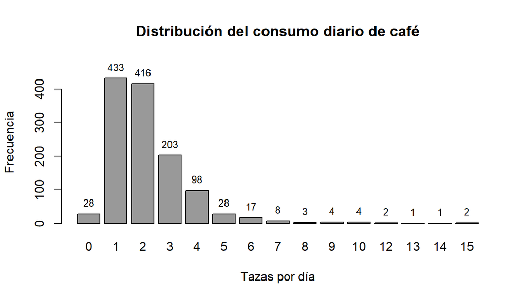

```r
tabla_tazas <- table(CAFE_OFICIAL$tazas_dia)
bp_tazas <- barplot(tabla_tazas,
                    main = "Distribución del consumo diario de café",
                    xlab = "Tazas por día",
                    ylab = "Frecuencia",
                    col = gray(0.6),
                    border = "black",
                    ylim = c(0, max(tabla_tazas) + 50))
text(x = bp_tazas, y = tabla_tazas, labels = tabla_tazas, pos = 3, cex = 0.8)
```

**Propuesta de modelo:**

Dado que:

1. La variable es un conteo de eventos (número de tazas)
2. Los valores son enteros no negativos
3. Media ≈ Varianza (2.20 ≈ 2.548 ≈ 2)
4. Los eventos (consumir cada taza) pueden considerarse independientes

Se propone modelar $X$ mediante una **distribución de Poisson con parámetro** $\lambda \approx 2.20$.

$$X \sim \text{Poisson}(\lambda = 2.20)$$

**Ajuste y validación gráfica:**

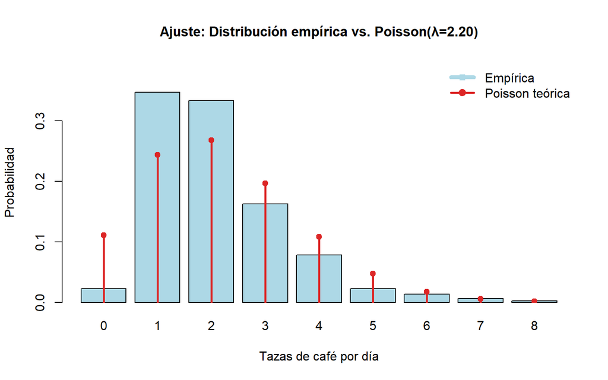

```r
lambda_est   <- mean(CAFE_OFICIAL$tazas_dia, na.rm = TRUE)
tabla_emp    <- table(CAFE_OFICIAL$tazas_dia)
prop_emp     <- tabla_emp / sum(tabla_emp)
valores      <- as.numeric(names(tabla_emp))
prob_poisson <- dpois(valores, lambda_est)

# Gráfico con zoom en región de mayor probabilidad (0–8 tazas)
valores_zoom <- 0:8
prob_poisson_zoom <- dpois(valores_zoom, lambda_est)

# Probabilidades empíricas correspondientes
prop_emp_zoom <- numeric(length(valores_zoom))
for (i in seq_along(valores_zoom)) {
  idx <- which(valores == valores_zoom[i])
  if (length(idx) > 0) {
    prop_emp_zoom[i] <- prop_emp[idx]
  }
}

bpc <- barplot(prop_emp_zoom,
               names.arg = valores_zoom,
               col = "lightblue",
               border = "black",
               ylim = c(0, max(prop_emp_zoom, prob_poisson_zoom, na.rm = TRUE) + 0.05),
               main = "Ajuste: Distribución empírica vs. Poisson(λ=2.20)",
               xlab = "Tazas de café por día",
               ylab = "Probabilidad",
               cex.main = 1.1, font.main = 2)

lines(bpc, prob_poisson_zoom, type = "h", lwd = 2.5, col = "#DC2626")
points(bpc, prob_poisson_zoom, col = "#DC2626", pch = 19, cex = 1)

legend("topright",
       legend = c("Empírica", "Poisson teórica"),
       col = c("lightblue", "#DC2626"),
       lwd = c(5, 2.5),
       pch = c(15, 19),
       bty = "n")
```

**Cálculos de probabilidades:**

```r
# P(X = k) para k = 2 y k = 3
prob_X_2 <- dpois(2, lambda_est)
prob_X_3 <- dpois(3, lambda_est)

cat("P(X = 2) =", round(prob_X_2, 4), "\n")
```

```
P(X = 2) = 0.2682
```

```r
cat("Interpretación: La probabilidad de que un estudiante consuma\n")
```

```
Interpretación: La probabilidad de que un estudiante consuma
```

```r
cat("exactamente 2 tazas de café en un día es del", round(prob_X_2 * 100, 2), "%\n\n")
```

```
exactamente 2 tazas de café en un día es del 26.82 %
```

```r
cat("P(X = 3) =", round(prob_X_3, 4), "\n")
```

```
P(X = 3) = 0.1966
```

```r
cat("Interpretación: La probabilidad de que un estudiante consuma\n")
```

```
Interpretación: La probabilidad de que un estudiante consuma
```

```r
cat("exactamente 3 tazas de café en un día es del", round(prob_X_3 * 100, 2), "%\n\n")
```

```
exactamente 3 tazas de café en un día es del 19.66 %
```

```r
# P(X ≤ 4) - No exceder el límite recomendado
prob_X_leq_4 <- ppois(4, lambda_est)
cat("P(X ≤ 4) =", round(prob_X_leq_4, 4), "\n")
```

```
P(X ≤ 4) = 0.9276
```

```r
cat("Interpretación: La probabilidad de que un estudiante consuma\n")
```

```
Interpretación: La probabilidad de que un estudiante consuma
```

```r
cat("4 tazas o menos (dentro del límite saludable) es del", round(prob_X_leq_4 * 100, 2), "%\n\n")
```

```
4 tazas o menos (dentro del límite saludable) es del 92.76 %
```

```r
# P(X ≥ 5) - Exceder el límite recomendado
prob_X_geq_5 <- 1 - ppois(4, lambda_est)
cat("P(X ≥ 5) =", round(prob_X_geq_5, 4), "\n")
```

```
P(X ≥ 5) = 0.0724
```

```r
cat("Interpretación: La probabilidad de que un estudiante consuma\n")
```

```
Interpretación: La probabilidad de que un estudiante consuma
```

```r
cat("5 o más tazas (excediendo el límite saludable) es del", round(prob_X_geq_5 * 100, 2), "%\n")
```

```
5 o más tazas (excediendo el límite saludable) es del 7.24 %
```

**Análisis final:**

**Implicaciones prácticas:**

### V.1.2 Horas de sueño (`sueno_noche`)

**Caso práctico:**

La dirección académica de UTEC desea identificar la proporción de estudiantes que duerme al menos 7 horas (mínimo recomendado para adultos jóvenes) y aquellos en riesgo por dormir 5 horas o menos.

**Pregunta motivadora:**

¿Qué modelo probabilístico describe las horas de sueño nocturno de los estudiantes consumidores de café en UTEC?

**Definición formal:**

Sea $Y$ la variable aleatoria:

$$Y = \text{número de horas que duerme un estudiante de UTEC en una noche}$$

donde $Y \in \{1, 2, 3, ..., 12\}$ (valores enteros positivos acotados).

**Análisis de descriptores:**

```r
media_sueno <- mean(CAFE_OFICIAL$sueno_noche, na.rm = TRUE)
var_sueno   <- var(CAFE_OFICIAL$sueno_noche, na.rm = TRUE)
dif_mv_sueno <- media_sueno - var_sueno

cat("Media:                    ", round(media_sueno, 3), "\n")
```

```
Media:                     5.677
```

```r
cat("Varianza:                 ", round(var_sueno, 3), "\n")
```

```
Varianza:                  2.445
```

```r
cat("Diferencia (μ - σ²):     ", round(dif_mv_sueno, 3), "\n\n")
```

```
Diferencia (μ - σ²):      3.232
```

```r
if (abs(dif_mv_sueno) < 0.5) {
  cat("Media ≈ Varianza → Poisson candidata\n")
} else if (dif_mv_sueno > 3) {
  cat("Media >> Varianza → Datos subdispersos, Poisson NO apropiada\n")
  cat("Considerar distribución empírica directa o modelos alternativos\n")
} else {
  cat("Media y varianza diferentes → Evaluar otros modelos\n")
}
```

```
Media >> Varianza → Datos subdispersos, Poisson NO apropiada
Considerar distribución empírica directa o modelos alternativos
```

**Visualización inicial:**

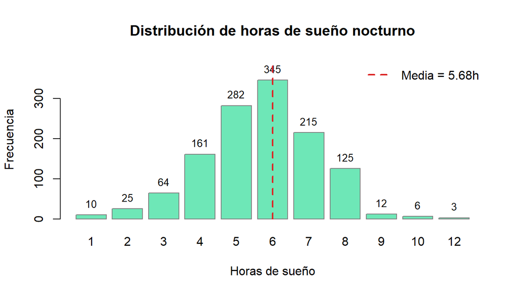

```r
tabla_sueno <- table(CAFE_OFICIAL$sueno_noche)
bp_sueno <- barplot(tabla_sueno,
                    main = "Distribución de horas de sueño nocturno",
                    xlab = "Horas de sueño",
                    ylab = "Frecuencia",
                    col = "#6EE7B7",
                    border = "gray50",
                    ylim = c(0, max(tabla_sueno) + 50))
text(x = bp_sueno, y = tabla_sueno, labels = tabla_sueno, pos = 3, cex = 0.85)
abline(v = bp_sueno[which.min(abs(as.numeric(names(tabla_sueno)) - media_sueno))],
       col = "#DC2626", lwd = 2, lty = 2)
legend("topright",
       legend = paste0("Media = ", round(media_sueno, 2), "h"),
       col = "#DC2626", lty = 2, lwd = 2, bty = "n")
```

**Descarte de modelos discretos:**

**Nota**

**¿Por qué los modelos discretos comunes no son apropiados?**

- **Poisson:** Requiere media ≈ varianza. Aquí μ = 5.677 y σ² = 2.445, con diferencia de 3.232 → **descartada**
- **Binomial:** Requiere n fijo y p constante. Las horas de sueño no son “éxitos” en n intentos → **descartada**
- **Geométrica:** Distribución decreciente desde inicio. El histograma muestra pico central en 6h → **descartada**
- **Hipergeométrica:** Muestreo sin reemplazo. No aplica a horas de sueño → **descartada**

**Conclusión:** Ningún modelo discreto estándar se ajusta adecuadamente. Se usará la **distribución empírica directa**.

**Cálculos con distribución empírica:**

```r
n_total <- sum(!is.na(CAFE_OFICIAL$sueno_noche))
sueno_freq <- as.data.frame(table(CAFE_OFICIAL$sueno_noche))
names(sueno_freq) <- c("horas", "freq")
sueno_freq$horas <- as.numeric(as.character(sueno_freq$horas))
sueno_freq$prob <- sueno_freq$freq / n_total

# P(Y = 6) - valor modal
prob_Y_6 <- sueno_freq$prob[sueno_freq$horas == 6]
cat("P(Y = 6) =", round(prob_Y_6, 4), "\n")
```

```
P(Y = 6) = 0.2764
```

```r
cat("Interpretación: La probabilidad de que un estudiante duerma\n")
```

```
Interpretación: La probabilidad de que un estudiante duerma
```

```r
cat("exactamente 6 horas es del", round(prob_Y_6 * 100, 2), "% (categoría modal)\n\n")
```

```
exactamente 6 horas es del 27.64 % (categoría modal)
```

```r
# P(Y ≤ 5) - En riesgo por sueño insuficiente
prob_Y_leq_5 <- sum(sueno_freq$prob[sueno_freq$horas <= 5])
cat("P(Y ≤ 5) =", round(prob_Y_leq_5, 4), "\n")
```

```
P(Y ≤ 5) = 0.4343
```

```r
cat("Interpretación: La probabilidad de que un estudiante duerma\n")
```

```
Interpretación: La probabilidad de que un estudiante duerma
```

```r
cat("5 horas o menos (sueño insuficiente) es del", round(prob_Y_leq_5 * 100, 2), "%\n\n")
```

```
5 horas o menos (sueño insuficiente) es del 43.43 %
```

```r
# P(Y ≥ 7) - Cumple recomendación mínima
prob_Y_geq_7 <- sum(sueno_freq$prob[sueno_freq$horas >= 7])
cat("P(Y ≥ 7) =", round(prob_Y_geq_7, 4), "\n")
```

```
P(Y ≥ 7) = 0.2893
```

```r
cat("Interpretación: La probabilidad de que un estudiante duerma\n")
```

```
Interpretación: La probabilidad de que un estudiante duerma
```

```r
cat("7 horas o más (cumple recomendación) es del", round(prob_Y_geq_7 * 100, 2), "%\n")
```

```
7 horas o más (cumple recomendación) es del 28.93 %
```

**Análisis final:**

**Implicaciones prácticas:**

## V.2 Variables continuas

### V.2.1 Promedio ponderado (`pp_2024_1`)

**Caso práctico:**

El departamento de Bienestar Académico desea estimar cuántos estudiantes consumidores de café tendrán un promedio ponderado en el rango de 13 a 16 puntos (categoría “aprobado satisfactoriamente”) para diseñar programas de apoyo focalizados.

**Pregunta motivadora:**

¿Qué distribución continua modela el rendimiento académico (PP) de los estudiantes consumidores de café en UTEC?

**Definición formal:**

Sea $Z$ la variable aleatoria continua:

$$Z = \text{promedio ponderado del ciclo 2024-1 de un estudiante de UTEC}, \quad Z \in [0, 20]$$

**Análisis visual inicial:**

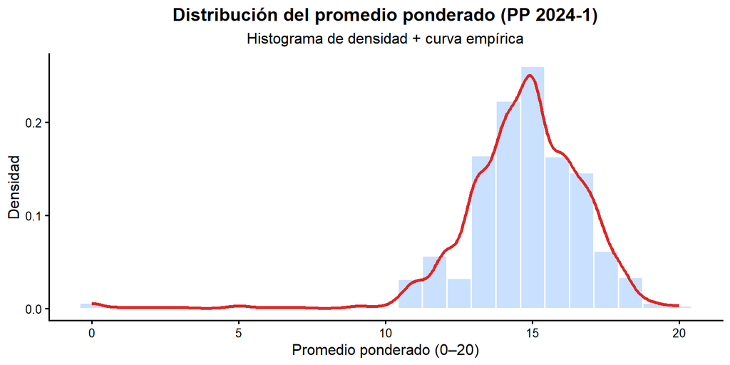

```r
pp_data <- CAFE_OFICIAL$pp_2024_1[!is.na(CAFE_OFICIAL$pp_2024_1)]

ggplot(data.frame(x = pp_data), aes(x = x)) +
  geom_histogram(aes(y = after_stat(density)), bins = 25,
                 fill = "#BFDBFE", color = "white", alpha = 0.85) +
  geom_density(color = "#DC2626", linewidth = 1.2) +
  labs(title = "Distribución del promedio ponderado (PP 2024-1)",
       subtitle = "Histograma de densidad + curva empírica",
       x = "Promedio ponderado (0–20)", y = "Densidad") +
  theme_classic(base_size = 12) +
  theme(plot.title = element_text(face = "bold", hjust = 0.5),
        plot.subtitle = element_text(hjust = 0.5))
```

**Descriptores numéricos:**

```r
n_pp     <- length(pp_data)
media_pp <- mean(pp_data)
mediana_pp <- median(pp_data)
sd_pp    <- sd(pp_data)
var_pp   <- var(pp_data)
cv_pp    <- sd_pp / media_pp
asim_pp  <- (sum((pp_data - media_pp)^3) / n_pp) / (sd_pp^3)

cat("n:                        ", n_pp, "\n")
```

```
n:                         1248
```

```r
cat("Media:                    ", round(media_pp, 3), "\n")
```

```
Media:                     14.689
```

```r
cat("Mediana:                  ", round(mediana_pp, 3), "\n")
```

```
Mediana:                   15
```

```r
cat("Desviación estándar:      ", round(sd_pp, 3), "\n")
```

```
Desviación estándar:       2.17
```

```r
cat("Varianza:                 ", round(var_pp, 3), "\n")
```

```
Varianza:                  4.707
```

```r
cat("Coeficiente de variación: ", round(cv_pp, 4), "\n")
```

```
Coeficiente de variación:  0.1477
```

```r
cat("Asimetría:                ", round(asim_pp, 4), "\n")
```

```
Asimetría:                 -2.2253
```

**Comparación de distribuciones candidatas:**

Se evalúan tres distribuciones candidatas mediante log-verosimilitud antes de seleccionar el modelo final.

```r
library(MASS)
pp_data_pos <- pp_data[pp_data > 0]
fit_gamma_pp <- fitdistr(pp_data_pos, "gamma")
alpha_gam_pp <- fit_gamma_pp$estimate["shape"]
rate_gam_pp  <- fit_gamma_pp$estimate["rate"]
theta_gam_pp <- 1 / rate_gam_pp
loglik_normal <- sum(dnorm(pp_data, mean(pp_data), sd(pp_data), log = TRUE))
loglik_gamma  <- sum(dgamma(pp_data_pos, shape = alpha_gam_pp, rate = rate_gam_pp, log = TRUE))
loglik_unif   <- sum(dunif(pp_data, 0, 20, log = TRUE))
tabla_cand_pp <- data.frame(
  Distribucion    = c("Normal(mu, sigma)", "Gamma(alpha, theta)", "Uniforme(0, 20)"),
  Parametros      = c(
    paste0("mu=", round(mean(pp_data), 2), ", sigma=", round(sd(pp_data), 2)),
    paste0("alpha=", round(alpha_gam_pp, 2), ", theta=", round(theta_gam_pp, 2)),
    "a=0, b=20"
  ),
  LogVerosimilitud = round(c(loglik_normal, loglik_gamma, loglik_unif), 2),
  Veredicto = c("SELECCIONADA", "Descartada: asimetria opuesta", "Descartada: densidad no constante")
)
kable(tabla_cand_pp, caption = "Tabla 5a. Comparacion de distribuciones candidatas - PP 2024-1",
      align = c("l","l","r","l")) %>%
  kable_styling(bootstrap_options = c("striped","hover"), full_width = FALSE)
```

Tabla 5a. Comparacion de distribuciones candidatas - PP 2024-1

| Distribucion | Parametros | LogVerosimilitud | Veredicto |
| --- | --- | --- | --- |
| Normal(mu, sigma) | mu=14.69, sigma=2.17 | -2736.93 | SELECCIONADA |
| Gamma(alpha, theta) | alpha=44.35, theta=0.33 | -2741.55 | Descartada: asimetria opuesta |
| Uniforme(0, 20) | a=0, b=20 | -3738.67 | Descartada: densidad no constante |

**Nota**

**Justificacion de seleccion:**

**Modelo propuesto:** Distribucion Normal

**Ajuste del modelo Normal:**

Parámetros estimados:

$$Z \sim N(\mu = 14.69, \sigma = 2.17)$$

```r
mu_pp <- media_pp
sigma_pp <- sd_pp

cat("Parámetros del modelo Normal:\n")
```

```
Parámetros del modelo Normal:
```

```r
cat("μ (media) =", round(mu_pp, 3), "\n")
```

```
μ (media) = 14.689
```

```r
cat("σ (DE)    =", round(sigma_pp, 3), "\n")
```

```
σ (DE)    = 2.17
```

**Validación gráfica:**

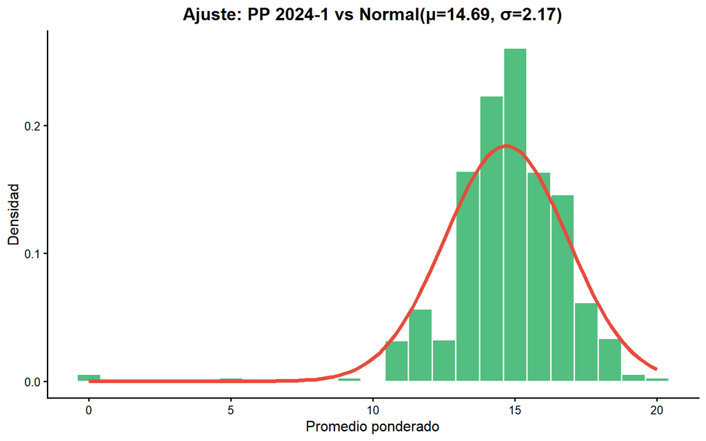

```r
ggplot(data.frame(x = pp_data), aes(x = x)) +
  geom_histogram(aes(y = after_stat(density)), bins = 25,
                 fill = "#27AE60", color = "white", alpha = 0.8) +
  stat_function(fun = dnorm, args = list(mean = mu_pp, sd = sigma_pp),
                color = "#E74C3C", linewidth = 1.5) +
  labs(title = paste0("Ajuste: PP 2024-1 vs Normal(μ=", round(mu_pp,2), ", σ=", round(sigma_pp,2), ")"),
       x = "Promedio ponderado", y = "Densidad") +
  theme_classic(base_size = 12) +
  theme(plot.title = element_text(face = "bold", hjust = 0.5))
```

**Q-Q Plot para validar normalidad:**

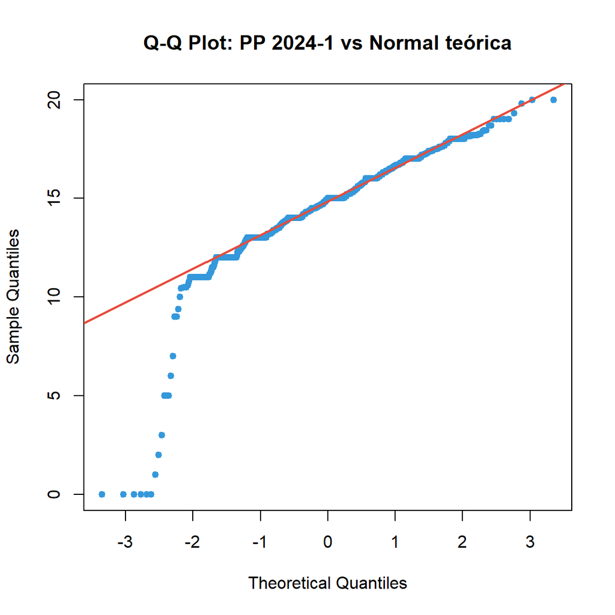

```r
qqnorm(pp_data, main = "Q-Q Plot: PP 2024-1 vs Normal teórica",
       col = "#3498DB", pch = 19, cex = 0.8)
qqline(pp_data, col = "#E74C3C", lwd = 2)
```

**Cálculos de probabilidades:**

```r
# P(13 ≤ Z ≤ 16) - Rango "aprobado satisfactoriamente"
prob_13_16 <- pnorm(16, mu_pp, sigma_pp) - pnorm(13, mu_pp, sigma_pp)
cat("P(13 ≤ Z ≤ 16) =", round(prob_13_16, 4), "\n")
```

```
P(13 ≤ Z ≤ 16) = 0.509
```

```r
cat("Interpretación: La probabilidad de que un estudiante tenga un PP\n")
```

```
Interpretación: La probabilidad de que un estudiante tenga un PP
```

```r
cat("entre 13 y 16 puntos es del", round(prob_13_16 * 100, 2), "%\n\n")
```

```
entre 13 y 16 puntos es del 50.9 %
```

```r
# P(Z < 11) - En riesgo académico
prob_Z_menor_11 <- pnorm(11, mu_pp, sigma_pp)
cat("P(Z < 11) =", round(prob_Z_menor_11, 4), "\n")
```

```
P(Z < 11) = 0.0445
```

```r
cat("Interpretación: La probabilidad de que un estudiante esté\n")
```

```
Interpretación: La probabilidad de que un estudiante esté
```

```r
cat("en riesgo académico (PP < 11) es del", round(prob_Z_menor_11 * 100, 2), "%\n\n")
```

```
en riesgo académico (PP < 11) es del 4.45 %
```

```r
# P(Z ≥ 17) - Rendimiento destacado
prob_Z_mayor_17 <- 1 - pnorm(17, mu_pp, sigma_pp)
cat("P(Z ≥ 17) =", round(prob_Z_mayor_17, 4), "\n")
```

```
P(Z ≥ 17) = 0.1434
```

```r
cat("Interpretación: La probabilidad de que un estudiante tenga\n")
```

```
Interpretación: La probabilidad de que un estudiante tenga
```

```r
cat("rendimiento destacado (PP ≥ 17) es del", round(prob_Z_mayor_17 * 100, 2), "%\n\n")
```

```
rendimiento destacado (PP ≥ 17) es del 14.34 %
```

```r
# Percentil 25 y 75
p25 <- qnorm(0.25, mu_pp, sigma_pp)
p75 <- qnorm(0.75, mu_pp, sigma_pp)
cat("Percentil 25: P₂₅ =", round(p25, 2), "\n")
```

```
Percentil 25: P₂₅ = 13.23
```

```r
cat("Percentil 75: P₇₅ =", round(p75, 2), "\n")
```

```
Percentil 75: P₇₅ = 16.15
```

```r
cat("Interpretación: El 50% central de estudiantes tiene PP entre",
    round(p25, 2), "y", round(p75, 2), "\n")
```

```
Interpretación: El 50% central de estudiantes tiene PP entre 13.23 y 16.15
```

**Análisis final:**

**Supuestos y limitaciones:**

- **Supuesto de independencia:** Se asume que el PP de un estudiante no afecta al de otro
- **Limitación del rango:** El modelo Normal permite valores negativos y >20, pero en la práctica el PP está acotado en [0,20]. Sin embargo, P(Z<0) y P(Z>20) son prácticamente 0 con estos parámetros
- **Aplicabilidad:** Válido solo para la población de estudiantes consumidores de café en 2024-2

**Implicaciones prácticas:**

### V.2.2 Límite de horas antes de dormir (`limite_dormir`)

**Caso práctico:**

La oficina de Salud Estudiantil desea estimar qué proporción de estudiantes consumiría café dentro de las 4 horas previas a dormir (conducta que afecta la calidad del sueño) para diseñar campañas de educación sobre higiene del sueño.

**Pregunta motivadora:**

¿Qué distribución continua modela la tolerancia temporal de los estudiantes al consumo de café antes de dormir?

**Definición formal:**

Sea $W$ la variable aleatoria continua:

$$W = \text{horas máximas antes de dormir en que un estudiante consumiría café}, \quad W > 0$$

Se excluyen valores W = 0 para analizar solo estudiantes que sí tienen algún límite temporal.

```r
w_data <- CAFE_OFICIAL$limite_dormir[CAFE_OFICIAL$limite_dormir > 0 & !is.na(CAFE_OFICIAL$limite_dormir)]
n_w <- length(w_data)
cat("Muestra efectiva (W > 0):", n_w, "estudiantes\n")
```

```
Muestra efectiva (W > 0): 1201 estudiantes
```

**Análisis visual inicial:**

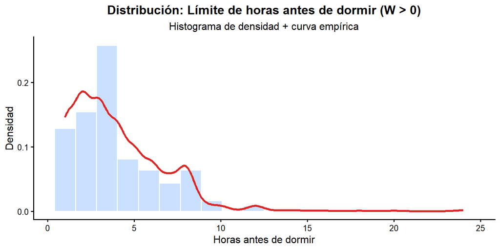

```r
ggplot(data.frame(x = w_data), aes(x = x)) +
  geom_histogram(aes(y = after_stat(density)), bins = 20,
                 fill = "#BFDBFE", color = "white", alpha = 0.85) +
  geom_density(color = "#DC2626", linewidth = 1.2) +
  labs(title = "Distribución: Límite de horas antes de dormir (W > 0)",
       subtitle = "Histograma de densidad + curva empírica",
       x = "Horas antes de dormir", y = "Densidad") +
  theme_classic(base_size = 12) +
  theme(plot.title = element_text(face = "bold", hjust = 0.5),
        plot.subtitle = element_text(hjust = 0.5))
```

**Descriptores numéricos:**

```r
media_w   <- mean(w_data)
mediana_w <- median(w_data)
sd_w      <- sd(w_data)
var_w     <- var(w_data)
cv_w      <- sd_w / media_w
asim_w    <- (sum((w_data - media_w)^3) / n_w) / (sd_w^3)

cat("Media:                    ", round(media_w, 3), "\n")
```

```
Media:                     4.003
```

```r
cat("Mediana:                  ", round(mediana_w, 3), "\n")
```

```
Mediana:                   3
```

```r
cat("Desviación estándar:      ", round(sd_w, 3), "\n")
```

```
Desviación estándar:       2.69
```

```r
cat("Varianza:                 ", round(var_w, 3), "\n")
```

```
Varianza:                  7.235
```

```r
cat("Coeficiente de variación: ", round(cv_w, 4), "\n")
```

```
Coeficiente de variación:  0.6719
```

```r
cat("Asimetría:                ", round(asim_w, 4), "\n")
```

```
Asimetría:                 1.7334
```

**Comparación de distribuciones candidatas:**

Se evaluan tres distribuciones de soporte positivo y se comparan mediante log-verosimilitud antes de seleccionar el modelo final.

```r
# Ajuste Gamma por MLE
fit_gamma_w <- fitdistr(w_data, "gamma")

alpha_mle_w <- fit_gamma_w$estimate["shape"]
rate_mle_w  <- fit_gamma_w$estimate["rate"]
theta_mle_w <- 1 / rate_mle_w  # parametrización en escala

# Ajustes alternativos
fit_weibull_w <- fitdistr(w_data, "weibull")
fit_lognorm_w <- fitdistr(w_data, "lognormal")

# Log-verosimilitudes
loglik_gamma_w <- sum(dgamma(w_data,
                             shape = alpha_mle_w,
                             rate  = rate_mle_w,
                             log   = TRUE))

loglik_weibull_w <- sum(dweibull(w_data,
                                 shape = fit_weibull_w$estimate["shape"],
                                 scale = fit_weibull_w$estimate["scale"],
                                 log   = TRUE))

loglik_lognorm_w <- sum(dlnorm(w_data,
                               meanlog = fit_lognorm_w$estimate["meanlog"],
                               sdlog   = fit_lognorm_w$estimate["sdlog"],
                               log     = TRUE))

tabla_cand_w <- data.frame(
  Distribucion = c("Gamma(alpha, theta)",
                   "Weibull(shape, scale)",
                   "Lognormal(meanlog, sdlog)"),
  Parametros = c(
    paste0("alpha=", round(alpha_mle_w, 3),
           ", theta=", round(theta_mle_w, 3)),
    paste0("shape=", round(fit_weibull_w$estimate["shape"], 3),
           ", scale=", round(fit_weibull_w$estimate["scale"], 3)),
    paste0("meanlog=", round(fit_lognorm_w$estimate["meanlog"], 3),
           ", sdlog=", round(fit_lognorm_w$estimate["sdlog"], 3))
  ),
  LogVerosimilitud = round(c(loglik_gamma_w,
                             loglik_weibull_w,
                             loglik_lognorm_w), 2),
  Veredicto = c("SELECCIONADA",
                "Candidata alternativa",
                "Descartada: cola excesiva")
)

kable(tabla_cand_w,
      caption = "Tabla 6a. Comparacion de distribuciones candidatas - limite_dormir",
      align = c("l","l","r","l")) %>%
  kable_styling(bootstrap_options = c("striped","hover"),
                full_width = FALSE)
```

Tabla 6a. Comparacion de distribuciones candidatas - limite_dormir

[output not shown]

**Nota**

**Justificacion de seleccion:**

**Método 1: Método de Momentos (MM)**

Fórmulas:

$$\alpha_{MM} = \frac{\bar{x}^2}{s^2}, \quad \theta_{MM} = \frac{s^2}{\bar{x}}$$

```r
alpha_mm_w <- (media_w^2) / var_w
theta_mm_w <- var_w / media_w

cat("Método de Momentos (MM):\n")
```

```
Método de Momentos (MM):
```

```r
cat("α (shape) =", round(alpha_mm_w, 4), "\n")
```

```
α (shape) = 2.2152
```

```r
cat("θ (scale) =", round(theta_mm_w, 4), "\n")
```

```
θ (scale) = 1.8072
```

```r
cat("Media teórica    = α·θ =", round(alpha_mm_w * theta_mm_w, 3), "\n")
```

```
Media teórica    = α·θ = 4.003
```

```r
cat("Varianza teórica = α·θ² =", round(alpha_mm_w * theta_mm_w^2, 3), "\n")
```

```
Varianza teórica = α·θ² = 7.235
```

```r
cat("Moda teórica     = (α-1)·θ =", round((alpha_mm_w - 1) * theta_mm_w, 3), "\n")
```

```
Moda teórica     = (α-1)·θ = 2.196
```

**Método 2: Máxima Verosimilitud (MLE)**

```r
library(MASS)
fit_gamma_w <- fitdistr(w_data, "gamma")
alpha_mle_w <- fit_gamma_w$estimate["shape"]
rate_mle_w  <- fit_gamma_w$estimate["rate"]
theta_mle_w <- 1 / rate_mle_w

cat("Máxima Verosimilitud (MLE):\n")
```

```
Máxima Verosimilitud (MLE):
```

```r
cat("α (shape) =", round(alpha_mle_w, 4), "\n")
```

```
α (shape) = 2.4274
```

```r
cat("θ (scale) =", round(theta_mle_w, 4), "\n")
```

```
θ (scale) = 1.6492
```

```r
cat("Media teórica    = α·θ =", round(alpha_mle_w * theta_mle_w, 3), "\n")
```

```
Media teórica    = α·θ = 4.003
```

```r
cat("Varianza teórica = α·θ² =", round(alpha_mle_w * theta_mle_w^2, 3), "\n")
```

```
Varianza teórica = α·θ² = 6.602
```

```r
cat("Moda teórica     = (α-1)·θ =", round((alpha_mle_w - 1) * theta_mle_w, 3), "\n")
```

```
Moda teórica     = (α-1)·θ = 2.354
```

**Comparación de ajustes:**

```r
comp_tabla <- data.frame(
  Característica = c("α (shape)", "θ (scale)", "Media teórica", "Varianza teórica", "Moda teórica"),
  MM  = c(round(alpha_mm_w, 4), round(theta_mm_w, 4),
          round(alpha_mm_w * theta_mm_w, 3),
          round(alpha_mm_w * theta_mm_w^2, 3),
          round((alpha_mm_w - 1) * theta_mm_w, 3)),
  MLE = c(round(alpha_mle_w, 4), round(theta_mle_w, 4),
          round(alpha_mle_w * theta_mle_w, 3),
          round(alpha_mle_w * theta_mle_w^2, 3),
          round((alpha_mle_w - 1) * theta_mle_w, 3))
)

kable(comp_tabla, caption = "Tabla 5. Comparación MM vs MLE",
      align = c("l","c","c")) %>%
  kable_styling(bootstrap_options = c("striped","hover"), full_width = FALSE)
```

Tabla 5. Comparación MM vs MLE

| Característica | MM | MLE |
| --- | --- | --- |
| α (shape) | 2.2152 | 2.4274 |
| θ (scale) | 1.8072 | 1.6492 |
| Media teórica | 4.0030 | 4.0030 |
| Varianza teórica | 7.2350 | 6.6020 |
| Moda teórica | 2.1960 | 2.3540 |

**Selección del modelo:**

Aunque el método de momentos MM reproduce exactamente la varianza muestral, el estimador por máxima verosimilitud se selecciona como modelo final, ya que este método determina los parámetros que hacen más probable la muestra observada bajo la distribución Gamma. El MLE proporciona un ajuste global más consistente con los datos, al considerar simultáneamente toda la información contenida en la muestra. **Se selecciona el modelo MLE.**

**Modelo final:**

$$\boxed{W \sim \text{Gamma}(\alpha = 2.4274, \theta = 1.6492)}$$

**Validación gráfica:**

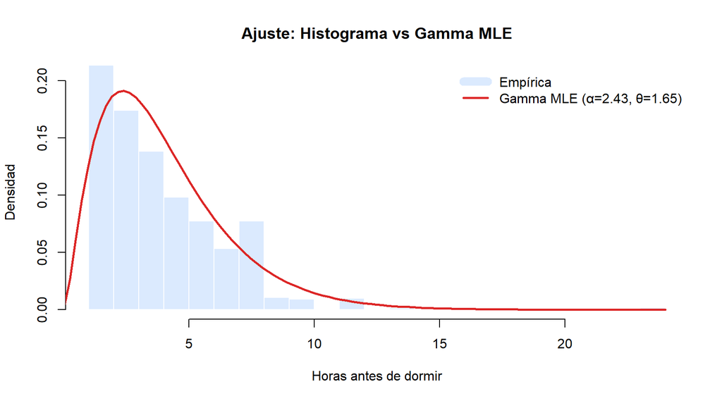

```r
hist(w_data, prob = TRUE, breaks = 20,
     col = "#DBEAFE", border = "white",
     main = "Ajuste: Histograma vs Gamma MLE",
     xlab = "Horas antes de dormir", ylab = "Densidad",
     ylim = c(0, max(density(w_data)$y) * 1.1))

curve(dgamma(x, shape = alpha_mle_w, rate = rate_mle_w),
      from = 0, to = max(w_data), col = "#DC2626", lwd = 2.5, add = TRUE)

legend("topright",
       legend = c("Empírica", paste0("Gamma MLE (α=", round(alpha_mle_w,2), ", θ=", round(theta_mle_w,2), ")")),
       col = c("#DBEAFE", "#DC2626"),
       lwd = c(10, 2.5),
       bty = "n")
```

**CDF empírica vs teórica:**

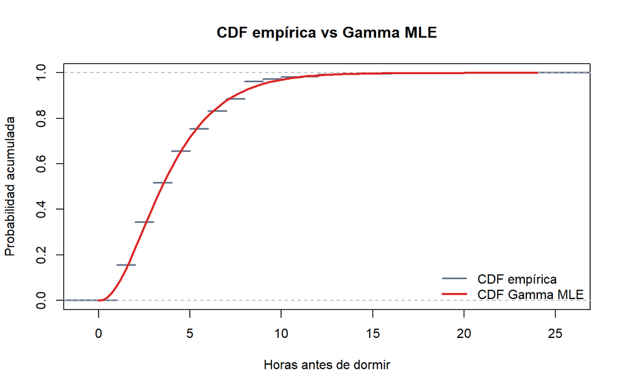

```r
plot(ecdf(w_data),
     main = "CDF empírica vs Gamma MLE",
     xlab = "Horas antes de dormir", ylab = "Probabilidad acumulada",
     col = "#64748B", lwd = 2, pch = NA)

curve(pgamma(x, shape = alpha_mle_w, rate = rate_mle_w),
      from = 0, to = max(w_data), col = "#DC2626", lwd = 2.5, add = TRUE)

legend("bottomright",
       legend = c("CDF empírica", "CDF Gamma MLE"),
       col = c("#64748B", "#DC2626"),
       lwd = c(2, 2.5),
       bty = "n")
```

**Cálculos de probabilidades:**

```r
# P(W ≤ 4) - Consumiría café dentro de 4h antes de dormir (afecta sueño)
prob_W_leq_4 <- pgamma(4, shape = alpha_mle_w, rate = rate_mle_w)
cat("P(W ≤ 4) =", round(prob_W_leq_4, 4), "\n")
```

```
P(W ≤ 4) = 0.5849
```

```r
cat("Interpretación: La probabilidad de que un estudiante consumiría\n")
```

```
Interpretación: La probabilidad de que un estudiante consumiría
```

```r
cat("café dentro de las 4 horas previas a dormir es del", round(prob_W_leq_4 * 100, 2), "%\n")
```

```
café dentro de las 4 horas previas a dormir es del 58.49 %
```

```r
cat("(conducta que afecta negativamente la calidad del sueño)\n\n")
```

```
(conducta que afecta negativamente la calidad del sueño)
```

```r
# P(W > 6) - Límite saludable (>6h de separación)
prob_W_mayor_6 <- 1 - pgamma(6, shape = alpha_mle_w, rate = rate_mle_w)
cat("P(W > 6) =", round(prob_W_mayor_6, 4), "\n")
```

```
P(W > 6) = 0.1883
```

```r
cat("Interpretación: La probabilidad de que un estudiante tenga un\n")
```

```
Interpretación: La probabilidad de que un estudiante tenga un
```

```r
cat("límite saludable (>6h de separación) es del", round(prob_W_mayor_6 * 100, 2), "%\n\n")
```

```
límite saludable (>6h de separación) es del 18.83 %
```

```r
# P(2 ≤ W ≤ 5) - Rango de tolerancia moderada
prob_2_a_5 <- pgamma(5, shape = alpha_mle_w, rate = rate_mle_w) -
              pgamma(2, shape = alpha_mle_w, rate = rate_mle_w)
cat("P(2 ≤ W ≤ 5) =", round(prob_2_a_5, 4), "\n")
```

```
P(2 ≤ W ≤ 5) = 0.4876
```

```r
cat("Interpretación: La probabilidad de que el límite esté entre\n")
```

```
Interpretación: La probabilidad de que el límite esté entre
```

```r
cat("2 y 5 horas es del", round(prob_2_a_5 * 100, 2), "%\n\n")
```

```
2 y 5 horas es del 48.76 %
```

```r
# Percentil 75
p75_w <- qgamma(0.75, shape = alpha_mle_w, rate = rate_mle_w)
cat("Percentil 75: P₇₅ =", round(p75_w, 2), "horas\n")
```

```
Percentil 75: P₇₅ = 5.32 horas
```

```r
cat("Interpretación: El 75% de estudiantes tiene un límite de",
    round(p75_w, 2), "horas o menos\n")
```

```
Interpretación: El 75% de estudiantes tiene un límite de 5.32 horas o menos
```

**Análisis final:**

El modelo Gamma(2.4274, 1.6492) proporciona un buen ajuste para la variable límite de horas antes de dormir:

- La CDF teórica sigue de cerca la CDF empírica
- La forma unimodal con cola derecha se captura adecuadamente
- Los parámetros estimados por MLE maximizan la verosimilitud de los datos observados

**Supuestos del modelo:**

1. **Valores positivos continuos:** Válido, W > 0 por construcción
2. **Independencia:** Se asume que el límite de un estudiante no afecta al de otro
3. **Distribución estable:** Se asume que el patrón no cambia dentro del periodo 2024-2

**Limitaciones:**

- El modelo sobrestima ligeramente la densidad en valores muy bajos (W < 1h)
- Para valores extremos (W > 15h), las frecuencias empíricas son escasas y el ajuste es menos preciso

**Implicaciones prácticas:**

# VI. Conclusiones

**Descriptivo:**

**Probabilístico:**

**Recomendaciones:**